# NYC Taxis Trips Demand Prediction

Weihan Li

May 4, 2019

### Introduction

#### Dataset

The dataset contains trip by trip data for NYC taxis in 2018, including fields capturing pick-up and drop-off dates/times, pick-up and drop-off locations, trip distances, itemized fares, rate types, payment types, and driver-reported passenger counts.

#### Project suggestion

1. Find important features of the demand for taxis, like daily cycles and weekly cycles.
2. Predict the amount of demand for taxis in a particular area

#### Why it’s meaningful

1. The same method can be applied to ride-sharing companies like Uber/Lyft to forecast demand. Demand prediction can be used to make pricing decisions to balance supply and demand.
2. For taxi companies, they can use this forecast to reduce labor cost by having more drivers work on the “peak” hours and fewer drivers work on the “off-peak” hours.

### Data Exploration And Visualization

The whole dataset is around 9.7GB, for illustration purposes, I’ll only use part of it to show some exploratory analysis. We aggregate the data into 15-minutes interval and extract some time features from the timestamp. The features considered here are **year**, **month**, **week**, **day**, **hour**, **weekday**, **hour of week** and **whether it’s a businessday**.

The processed data frame is shown below.

Processed data frame

| interval_time | date | year | month | week | day | hour | minute_interval | weekday | weekday_char | hourofweek | is_businessday | n_trips |
| --- | --- | --- | --- | --- | --- | --- | --- | --- | --- | --- | --- | --- |
| 2018-11-24 08:15:00 | 2018-11-24 | 2018 | 11 | 47 | 24 | 8 | 1 | 6 | Saturday | 128 | FALSE | 690 |
| 2018-11-24 08:30:00 | 2018-11-24 | 2018 | 11 | 47 | 24 | 8 | 2 | 6 | Saturday | 128 | FALSE | 1367 |
| 2018-11-24 08:45:00 | 2018-11-24 | 2018 | 11 | 47 | 24 | 8 | 3 | 6 | Saturday | 128 | FALSE | 1551 |
| 2018-11-24 09:00:00 | 2018-11-24 | 2018 | 11 | 47 | 24 | 9 | 0 | 6 | Saturday | 129 | FALSE | 1594 |
| 2018-11-24 09:15:00 | 2018-11-24 | 2018 | 11 | 47 | 24 | 9 | 1 | 6 | Saturday | 129 | FALSE | 1791 |
| 2018-11-24 09:30:00 | 2018-11-24 | 2018 | 11 | 47 | 24 | 9 | 2 | 6 | Saturday | 129 | FALSE | 1943 |

#### Day Trend

Do people take taxis on Friday as frequent as Monday? The intuitive answer is no. let’s see what the data says. The chart below shows the average number of trips per weekday and weekend

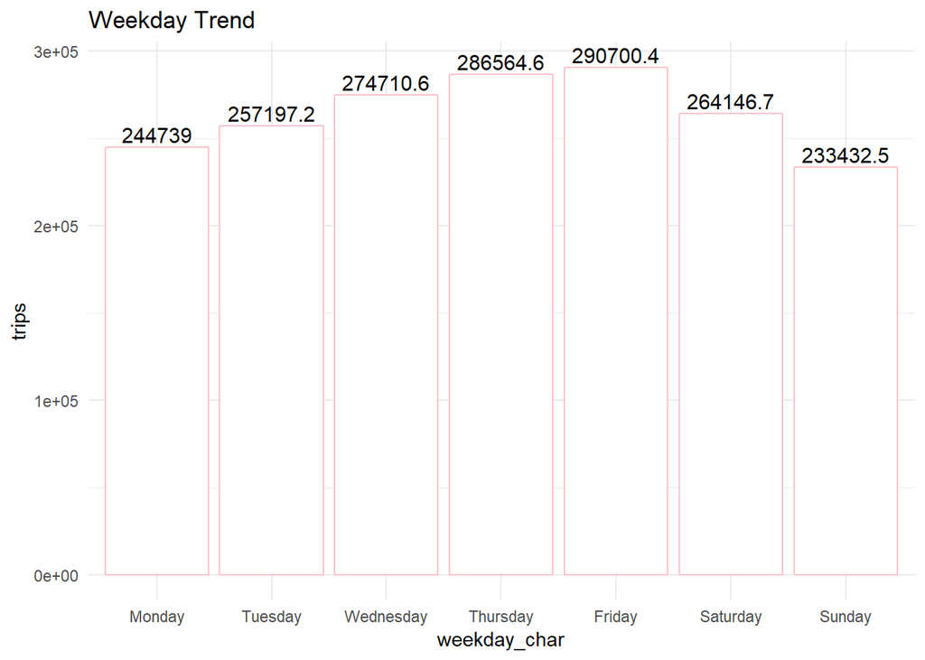

As we can see, number of trips keeps increasing from Monday to Friday, and falling back during the weekend. Sunday and Monday has the lowest trips and Friday has the highest trips. Is there any specific reason for such pattern?

The next plot shows the average hourly trips in a week from Monday 00:00 am to Sunday 11:59pm.

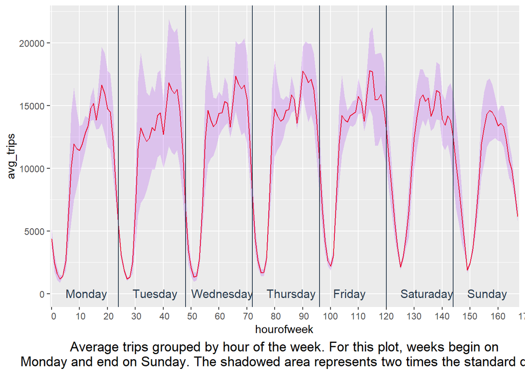

With this plot, things become clear.

For each day, we have a **“morning peak”** around 8 AM and an **“evening peak”** around 6 PM. and The variance for peak hours(8 AM to 10 PM) is pretty high, which means it’s harder for us to predict peak hours than to predict off-peak hours( 11 PM to 7 AM), this will be showed in later prediction model.

The daily pattern is very simlar during weekdays, but it’s very different between weekdays and weekends. On Saturday and Sunday, we don’t see a spike during evening peak hour, because people don’t need to take taxis home after work as they do on weekdays.

Non-businessday includes weekends and holidays, let’s see the difference between businessday and non-businessday.

#### Hourly Trend

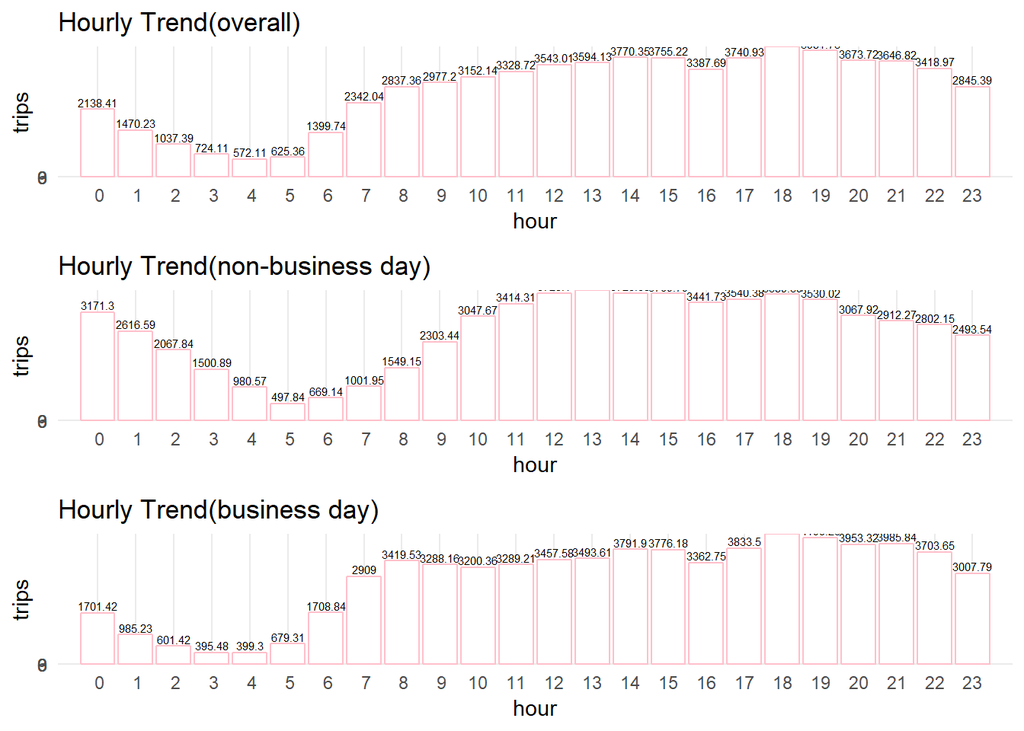

The businessday trend matches with the previous observation. The morning peak is around 8 AM and the evening peak is around 19:00 PM. Since Most of the days are businessday, the overall trend is very close to businessday trend.

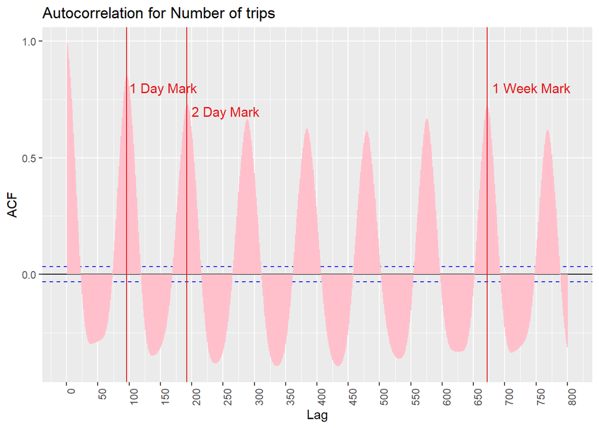

As we can see, demand(number of trips) is highly correlated with itself at 1 lag(15 minutes ago), 96 lag(1 day ago), 192 lag(2 day ago)…  
If we order it by the correlation, we’ll have

…

Intuitively, if we use last 15 minutes demand as a prediction for cureent interval’s demand, it won’t be too bad. But, how important are these lagged features when comparing to the features we mentiond above? We need to dive into the real model.

#### Next Steps

1. With the feature we extracted above, we can built different models to foreacast the demand for taxis. Models we can try:
- ARIMA: Basic time-series model
- LSTM: Since we have a huge dataset(around 10GB), deep learning method should be a good method.
- XGBoost, SVM, RF and other ML models
2. Evaluate their performance(RMSE, MAPE…) and choose the best model